# Variable Selection in Multiple Regression

**What is model selection?**

**Why use model selection?**

1. Lots of available predictor variables

`evals`:

| ID | prof_ID | score | age | bty_avg | gender | ethnicity | language | rank | pic_outfit | pic_color | cls_did_eval | cls_students | cls_level |
| --- | --- | --- | --- | --- | --- | --- | --- | --- | --- | --- | --- | --- | --- |
| 294 | 56 | 4.4 | 32 | 3.833 | male | not minority | english | tenure track | formal | black&white | 20 | 22 | upper |
| 219 | 40 | 4.3 | 42 | 4.000 | male | not minority | english | tenure track | not formal | color | 14 | 14 | upper |
| 220 | 40 | 4.9 | 42 | 4.000 | male | not minority | english | tenure track | not formal | color | 13 | 14 | upper |

2. Interested in prediction not explanation

> You want to predict an outcome variable $y$ based on the information contained in a set of predictor variables $x$. You don’t care so much about understanding how all the variables relate and interact with one another, but rather only whether you can make good predictions about $y$ using the information in $x$.

> *ModernDive*

How do you use model selection?

- Stepwise Selection
  - Forward Selection
  - Backward Selection
- Resampling Methods
  - Cross Validation
  - Testing / Training Datasets

**With any of these methods, you get to choose *how* you decide if one model is better than another model.**

$R^2$ – Coefficient of Determination

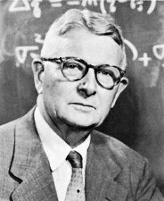

Wright, Sewall. 1921. Correlation and causation. Journal of Agricultural Research 20: 557-585.

> In statistics, the coefficient of determination, denoted $R^2$ or $r^2$ and pronounced “R squared,” is the proportion of the variation in the dependent variable that is predictable from the independent variable(s).

> *Wikipedia*

$R^2 = 1 - \frac{\text{var}(\text{residuals})}{\text{var}(y)}$

- $\text{var}(\text{residuals})$ is the variance of the residuals “leftover” from the regression model
- $\text{var}(y)$ is the inherent variability of the response variable

**Suppose we have a simple linear regression with an $R^2$ of 0.85. How would you interpret this quantity?**

But! $R^2$ **always** increases as you increase the number of explanatory variables.

**Simple Linear Regression**

$0.85 = 1 - \frac{0.75}{5}$

**One Additional Variable**

$0.86 = 1 - \frac{0.7}{5}$

Adjusted $R^2$

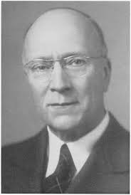

> The use of an adjusted $R^2$ is an attempt to account for the phenomenon of the $R^2$ automatically increasing when extra explanatory variables are added to the model.

> *Wikipedia*

$R^2_{adj} = 1 - \frac{\text{var(residuals)}}{\text{var}(y)} \times \frac{(n - 1)}{(n - k - 1)}$

- $n$ is the sample size
- $k$ is the number of predictor variables in the model

**Suppose you have a two categorical variables included in your regression, one with 7 levels and one with 4 levels. What value will you use for $k$ in the calculation of $n - k - 1$?**

p-values

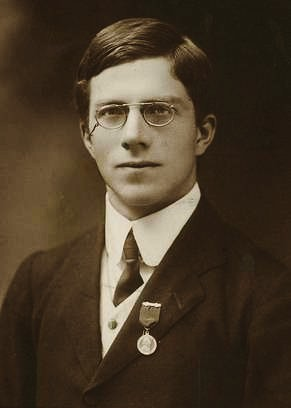

> In null-hypothesis significance testing, the p-value is the probability of obtaining test results at least as extreme as the result actually observed, under the assumption that the null hypothesis is correct. A very small p-value means that such an extreme observed outcome would be very unlikely under the null hypothesis.

> *Wikipedia*

AIC – An Information Criterion

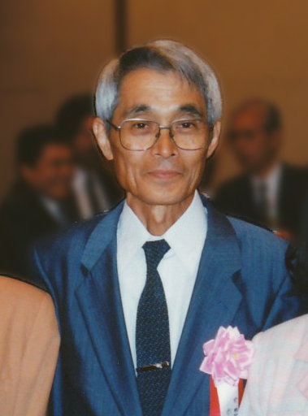

> The Akaike information criterion (AIC) is an estimator of prediction error and thereby relative quality of statistical models for a given set of data. Given a collection of models for the data, AIC estimates the quality of each model, relative to each of the other models.

> *Wikipedia*

Well, how do you use AIC to choose a “best” model?

| model | AIC | Delta AIC |
| --- | --- | --- |
| Full Model | 4724.970 | 0.000000 |
| All Variables Except Year | 4727.242 | 2.272501 |
| All Variables Except Flipper Length | 4757.214 | 32.244605 |
| All Variables Except Species | 4793.681 | 68.710933 |

If you’ve ever assessed whether $\Delta$ AIC $> 2$ you have done something that is mathematically close to $p > 0.05$.

Model Selection Activity!

What should you use instead?

> In fact, many statisticians discourage the use of stepwise regression alone for model selection and advocate, instead, for a more thoughtful approach that carefully considers the research focus and features of the data.

> *Introduction to Modern Statistics*